## Monte Carlo Method for $\pi$

Monte Carlo methods can be thought of as statistical simulation methods that utilize a sequences of random numbers to perform the simulation. The name “Monte Carlo’’ was coined by Nicholas Constantine Metropolis (1915-1999) and inspired by Stanslaw Ulam (1909-1986), because of the similarity of statistical simulation to games of chance, and because Monte Carlo is a center for gambling and games of chance.

## Graph of a circle

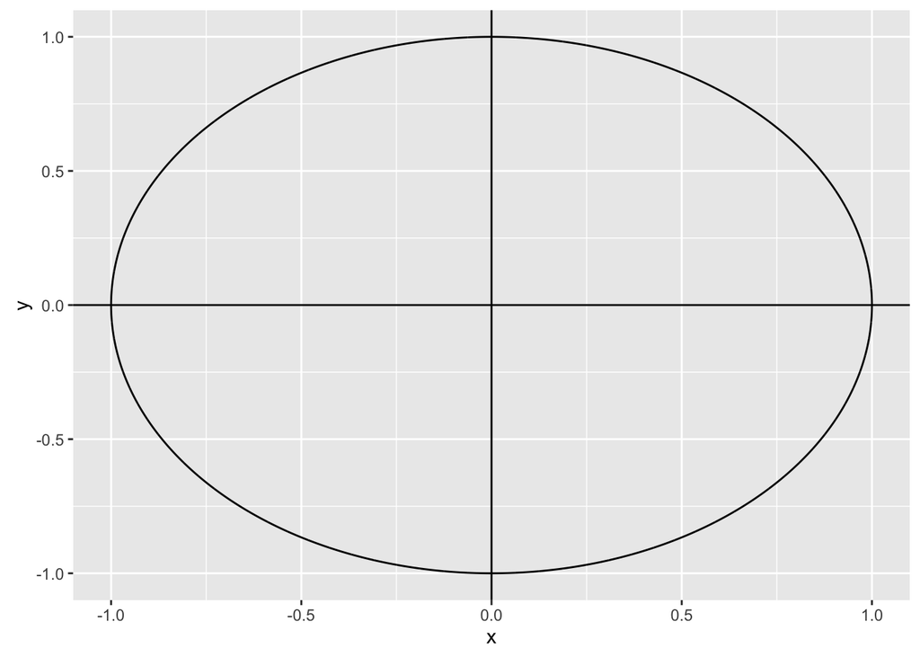

```r
library(ggplot2)
circleFun <- function(center, diameter, npoints) {
    r = diameter/2
    tt <- seq(0, 2 * pi, length.out = npoints)
    xx <- center[1] + r * cos(tt)
    yy <- center[2] + r * sin(tt)
    return(data.frame(x = xx, y = yy))
}

dat <- circleFun(c(0, 0), 2, npoints = 10000)
ggplot(dat, aes(x, y)) + geom_path() + geom_vline(xintercept = 0) + geom_hline(yintercept = 0) +
    xlim(-1, 1) + ylim(-1, 1)
```

Let us consider the graph above as the target of dart. The length of the unit square is 2. Therefore, the radius of the circle is 1. By law of the large number, if we have sufficient large number of darts, the probability of hitting within the circle would be the area of the circle, which is $\pi r^2 = \pi$. By the same reason, the probability of hitting within the unit square would be its area, which is 4. The ratio of areas is
$$\frac{Prob(circle)}{Prob(square)} = \frac{area(circle)}{area(square)} = \frac{\pi}{4}$$
Therefore,
$$\pi = 4*\frac{Prob(circle)}{Prob(square)}$$
If we have sufficient large number of darts.

Here are the codes for simulation

```r
set.seed(123)
x <- runif(2000, min = 0, max = 1)
y <- runif(2000, min = 0, max = 1)

pai <- function(x, y) {
    k = 0
    for (i in 1:length(x)) {
        for (j in 1:length(y)) {
            k = k + ifelse(((x[i])^2 + (y[j])^2) <= 1, 1, 0)
        }
    }
    p = 4 * k/(length(x) * length(y))
    return(p)
}

pai(x, y)
```

```
[1] 3.140121
```

As we can see, if we plot $2000^2$ dots, $\pi$ can be estimated as 3.140121. Every time a Monte Carlo simulation is made using the same sample size it will come up with a slightly different value. The values converge very slowly. This property is a consequence of the Central Limit Theorem.